# HW1_201724570

Jeong Seok Gyu

2022-10-04

```
Student information

- Student name : 정석규
- Major : 전기공학과
- Student id : 201724570
```

## Table of Contents

1. Introduction
2. Problem 1
3. Problem 2
4. Problem 3
5. Problem 4
6. Problem 5
7. Problem 6

# Introduction

Open the data set Boston in the $R$ package $MASS$. The data information is available with ?Boston. It has a total of $n = 506$ observations with 14 variables, where the variable $crim$ is considered as a response and the other 13 variables ar considered as predictors. So, you can make the predictor $x$ and the response $y$ using the following R codes.

```
data(Boston)
y <- Boston[, 1]
x <- Boston[, -1]
```

We want to find the best subset among 13 predictors associated with the response $y$. In order to find the best model, you have to consider a total of $2^{13} - 1 = 8,191$ models. Let us define the log-likelihood function $l(\theta)$, $AIC$(Akaike information criterion) and $BIC$(Bayesian information criterion) as

$$l(\theta) = \sum_{i=1}^{n}
\log{(\frac{1}{\sqrt{2\pi}\sigma}exp(-\frac{(y_i - \beta_0 - x_i^T
\beta)^2}{2\sigma^2}))}$$
$$AIC(\theta) = -2 l(\theta) + 2d$$
$$BIC(\theta) = -2l(\theta) + d \log{n}$$
respectively. The parameter vector $\theta = (\beta_0, \beta, \sigma)$ and $d$ is the number of regression coefficient in the model. Note that $d \ge 1$ since an intercept parameter $\beta_0$ is always in the model.

```r
# ---------- Introduction ---------- #
# Importing packages
## install.packages('MASS')
## install.packages('leaps')
## install.packages('glmnet')￣
library(glmnet)
library(MASS)
library(leaps)
library(dplyr)

# Importing Datasets
data(Boston)
dim(Boston)
```

```
## [1] 506  14
```

```r
# Make predictor x and the response y
y <- Boston[, 1]
x <- Boston[, -1]
```

```r
# Predefined function log-likelihood, AIC and BIC.

# 1. Predicting function for best subsets.
predict.regsubsets <- function(x, coefi, ...) {
  mat.x <- model.matrix(~., x)
  xvars <- names(coefi)
  pred <- mat.x[, xvars] %*% coefi
  return(pred)
}

# 2. log-likelihood function
likelihood <- function(x, y, coefi, sigma){
  pred <- predict.regsubsets(x, coefi)
  exp_term = exp(-(y - pred)^2 / (2 * sigma^2))
  res <- sum(log(exp_term / (sqrt(2 * pi) * sigma)))
  return(res)
}

# 3. AIC(Akaike information criterion)
aic <- function(ltheta, d) {
  res <- (-2 * ltheta) + (2 * d)
  return(res)
}

# 4. BIC(Bayesian information criterion)
bic <- function(ltheta, d, n) {
  res <- (-2 * ltheta) + (d * log(n))
  return(res)
}
```

```r
# Pre-define most used variables
n <- nrow(x)
ybar <- mean(y)
```

# Problem 1

With the ordinary least square estimate $(\hat{\beta_0^{ols}}, \hat{\beta^{ols}})$ and the plug-in estimate $\hat{\sigma_1} = \sqrt{\frac{1}{n-1}\sum_{i=1}^n(y_i - \bar{y})^2}$, find the best subset model that can minimize $AIC$ and $BIC$, respectively. For each best subset, clearly specify which variables are included in the final model along with the numerical values of $AIC$ and $BIC$.

```r
# ---------- Problem1 ---------- #
# Training model with the ordinary square estimate
# Workflows of problem 1
# 1. Fit all (p=13, k) models that contains exactly k predictors.
# 2. Pick the best among these (p=13, k) models, and call it M_k. (We will do this by using regsubsets function.)
# 3. Select a single best model from among M_0, M_1, ... M_13 using AIC and BIC.
#   3.1 Calculate coefi, d, sigma1 from each k.
#   3.2 Calculate log-likelihood values from likelihood function.
# 4. Evaluate each model using AIC and BIC and store the results in metrics1.

# \sigma 1
sigma_formula1 <- function(y, ybar, n) {
  res <- sqrt(sum((y - ybar)^2) / (n - 1))
  return(res)
}

# train the best subset selection model
g1 <- regsubsets(x, y, nvmax=13, nbest=1)

# model evaluation
metrics1 <- matrix(0, 13, 2)
for (i in 1:13) {
  coefi <- coef(g1, id=i)
  d <- length(coefi)
  sigma1 <- sigma_formula1(y, ybar, n)
  ltheta <- likelihood(x, y, coefi, sigma1)
  metrics1[i, 1] <- aic(ltheta, d)
  metrics1[i, 2] <- bic(ltheta, d, n)
}

# find the smallest number of variables based on AIC and BIC
colnames(metrics1) <- c('AIC', 'BIC')
metrics1
```

```
##            AIC      BIC
##  [1,] 3419.146 3427.599
##  [2,] 3406.229 3418.908
##  [3,] 3404.282 3421.188
##  [4,] 3403.819 3424.952
##  [5,] 3402.898 3428.257
##  [6,] 3402.502 3432.088
##  [7,] 3402.663 3436.475
##  [8,] 3403.248 3441.287
##  [9,] 3404.248 3446.514
## [10,] 3405.937 3452.429
## [11,] 3407.683 3458.401
## [12,] 3409.459 3464.404
## [13,] 3411.456 3470.627
```

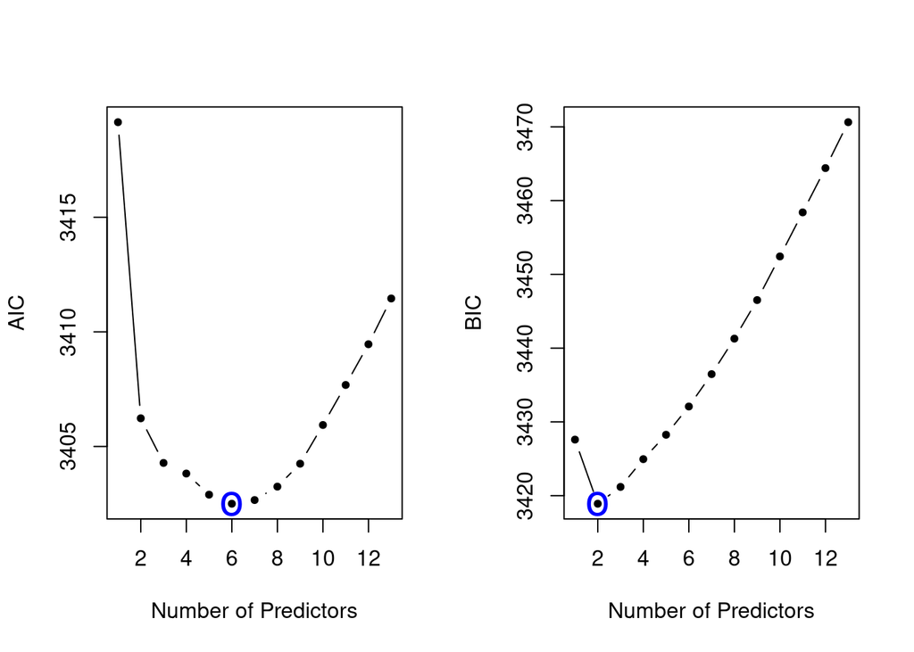

```r
wm.a1 <- which.min(metrics1[, 1])
wm.b1 <- which.min(metrics1[, 2])

# Visualization of metrics plot
par(mfrow=c(1,2))
plot(1:13, metrics1[, 1], type="b", pch=20, xlab="Number of Predictors", ylab="AIC")
points(wm.a1, metrics1[wm.a1, 1], pch="o", col="blue", cex=2)
plot(1:13, metrics1[, 2], type="b", pch=20, xlab="Number of Predictors", ylab="BIC")
points(wm.b1, metrics1[wm.b1, 2], pch="o", col="blue", cex=2)
```

```r
# Print Results
cat("The variables included in final model based on AIC : ", names(coef(g1, id=wm.a1)[-1]), sep="\t")
```

```
## The variables included in final model based on AIC :     zn  nox dis rad black   medv
```

```r
cat("The number of variables included in final model based on AIC : ", length(names(coef(g1, id=wm.a1))) - 1)
```

```
## The number of variables included in final model based on AIC :  6
```

```r
cat("The value of its AIC : ", metrics1[wm.a1, 1])
```

```
## The value of its AIC :  3402.502
```

```r
cat("The variables included in final model based on BIC : ", names(coef(g1, id=wm.b1))[-1], sep="\t")
```

```
## The variables included in final model based on BIC :     rad lstat
```

```r
cat("The number of variables included in final model based on BIC : ", length(names(coef(g1, id=wm.b1))) - 1)
```

```
## The number of variables included in final model based on BIC :  2
```

```r
cat("The value of its BIC : ", metrics1[wm.b1, 2])
```

```
## The value of its BIC :  3418.908
```

# Problem 2

Repeat Q1, replacing $\hat{\sigma_1}$ with $\hat{\sigma_2} = \sqrt{\frac{1}{n-d}\sum_{i=1}^n(y_i - \hat{\beta_0^{ols}} - x_i^T \hat{\beta^{ols}}^2)}$

```r
# ---------- Problem2 ---------- #
# Repeat Q1 replacing sigma1 with sigma2.
# Workflows of solving problem 2.
# 1. Define sigma2 formula within sigma_formula2 function.
# 2. Repeat the same steps what we done in Problem1.

# \sigma 2
sigma_formula2 <- function(x, y, coefi, n, d) {
  pred <- predict.regsubsets(x, coefi)
  res <- sqrt(sum((y- pred)^2) / (n - d))
  return(res)
}

# train the best subset selection model
g2 <- regsubsets(x, y, nvmax=13, nbest=1)

# model evaluation : this tasks will be same without applying different sigma
metrics2 <- matrix(0, 13, 2)
for (i in 1:13) {
  coefi <- coef(g2, id=i)
  d <- length(coefi)
  sigma2 <- sigma_formula2(x, y, coefi, n, d)
  ltheta <- likelihood(x, y, coefi, sigma2)
  metrics2[i, 1] <- aic(ltheta, d)
  metrics2[i, 2] <- bic(ltheta, d, n)
}

# find the smallest number of variables based on AIC and BIC
colnames(metrics2) <- c("AIC", "BIC")
metrics2
```

```
##            AIC      BIC
##  [1,] 3365.576 3374.030
##  [2,] 3342.412 3355.091
##  [3,] 3337.544 3354.450
##  [4,] 3335.216 3356.348
##  [5,] 3332.033 3357.393
##  [6,] 3329.748 3359.333
##  [7,] 3328.437 3362.249
##  [8,] 3327.881 3365.920
##  [9,] 3328.074 3370.339
## [10,] 3329.525 3376.017
## [11,] 3331.083 3381.801
## [12,] 3332.698 3387.643
## [13,] 3334.719 3393.890
```

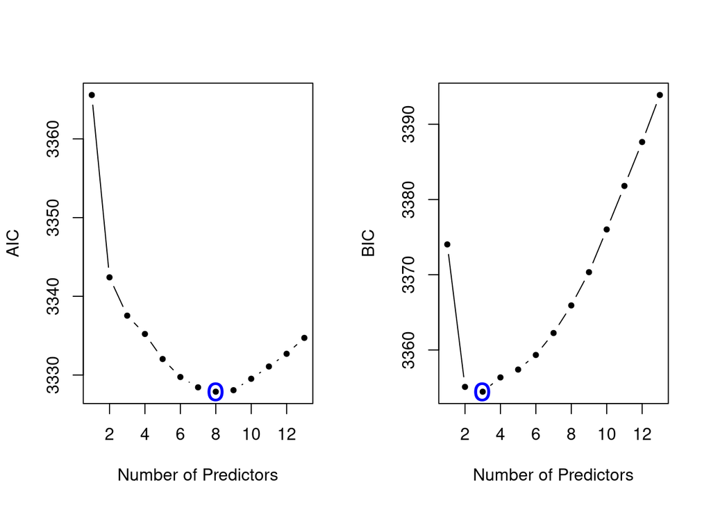

```r
wm.a2 <- which.min(metrics2[, 1])
wm.b2 <- which.min(metrics2[, 2])

# Visualization of metrics plot
par(mfrow=c(1,2))
plot(1:13, metrics2[, 1], type="b", pch=20, xlab="Number of Predictors", ylab="AIC")
points(wm.a2, metrics2[wm.a2, 1], pch="o", col="blue", cex=2)
plot(1:13, metrics2[, 2], type="b", pch=20, xlab="Number of Predictors", ylab="BIC")
points(wm.b2, metrics2[wm.b2, 2], pch="o", col="blue", cex=2)
```

```r
# Print Results
cat("The variables included in final model based on AIC : ", names(coef(g2, id=wm.a2)[-1]), sep="\t")
```

```
## The variables included in final model based on AIC :     zn  nox dis rad ptratio black   lstat   medv
```

```r
cat("The number of variables included in final model based on AIC : ", length(names(coef(g2, id=wm.a2))) - 1)
```

```
## The number of variables included in final model based on AIC :  8
```

```r
cat("The value of its AIC : ", metrics2[wm.a2, 1])
```

```
## The value of its AIC :  3327.881
```

```r
cat("The variables included in final model based on BIC : ", names(coef(g2, id=wm.b2))[-1], sep="\t")
```

```
## The variables included in final model based on BIC :     rad black   lstat
```

```r
cat("The number of variables included in final model based on BIC : ", length(names(coef(g2, id=wm.b2))) - 1)
```

```
## The number of variables included in final model based on BIC :  3
```

```r
cat("The value of its BIC : ", metrics1[wm.b2, 2])
```

[output not shown]

# Problem 3

Fit lasso with all of 13 predictors to find the best subset among 1,000 different $\lambda$ values. You don’t need to consider 8.191 models here. Use the following R code to generate the $\lambda$ values.

```
lambda <- 10^seq(0.8, -3, length=1000)
```

With the lasso estimate $(\hat{\beta_0^{lasso}}, \hat{\beta^{lasso}})$ and the plug-in estimator $\hat{\sigma_1}$, find the best subset models that can minimize the $AIC$ and $BIC$, respectively. For each best subset, clearly specify which variables are included in the final model along with the numerical values of $AIC$ and $BIC$.

```r
# ---------- Problem3 ---------- #
# In this problem, we need to apply hyperparameter thunig using lambda grid.
# Workflows of Problem 3
# 1. Define lambda grid.
# 2. Train model in lambda grid.
# 3. Repeat the steps through the lambda grid.
#   3.1 Calculate degree of freedom and prediction from each lambda.
#   3.2 Calculate AIC and BIC from prediction and store results into metrics3.
# 4. Evaluate models.

# Define new function for calculating log-likelihood
likelihood2 <- function(y, pred, sigma){
  exp_term = exp(-(y - pred)^2 / (2 * sigma^2))
  res <- sum(log(exp_term / (sqrt(2 * pi) * sigma)))
  return(res)
}

# Set hyper parameters grid lambda
lambda <- 10^seq(0.8, -3, length=1000)

# training model
g3 <- glmnet(x, y, alpha=1, lambda=lambda)

# model evaluation
metrics3 <- matrix(0, length(g3$lambda), 2)
for (i in 1:length(g3$lambda)) {
  d <- g3$df[i] + 1
  pred <- predict(g3, s=g3$lambda[i], newx=model.matrix(~., x)[,-1])
  ltheta <- likelihood2(y, pred, sigma1)
  metrics3[i, 1] <- aic(ltheta, d)
  metrics3[i, 2] <- bic(ltheta, d, n)
}

# find the smallest number of variables based on AIC and BIC
colnames(metrics3) <- c('AIC', 'BIC')
metrics3[sample(1:800, 10, replace=FALSE),]
```

```
##            AIC      BIC
##  [1,] 3407.770 3433.129
##  [2,] 3422.214 3443.347
##  [3,] 3413.186 3434.319
##  [4,] 3614.731 3618.957
##  [5,] 3411.530 3470.701
##  [6,] 3409.910 3443.723
##  [7,] 3409.408 3460.127
##  [8,] 3407.903 3441.716
##  [9,] 3411.478 3470.650
## [10,] 3408.644 3459.362
```

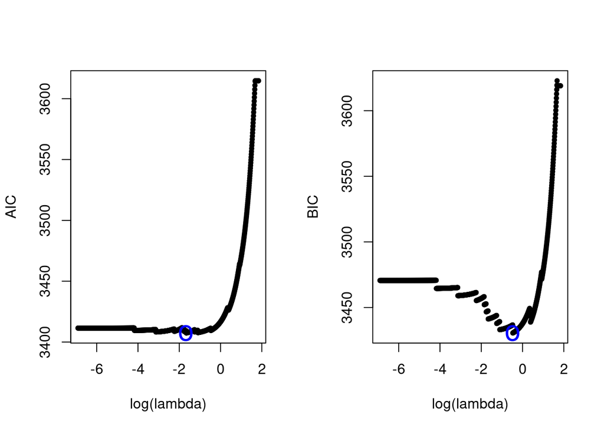

```r
wm.a3 <- which.min(metrics3[, 1])
wm.b3 <- which.min(metrics3[, 2])

# Visualization of metrics plot
par(mfrow=c(1,2))
plot(log(g3$lambda), metrics3[, 1], type="b", pch=20, xlab="log(lambda)", ylab="AIC")
points(log(g3$lambda)[wm.a3], metrics3[wm.a3, 1], pch="o", col="blue", cex=2)
plot(log(g3$lambda), metrics3[, 2], type="b", pch=20, xlab="log(lambda)", ylab="BIC")
points(log(g3$lambda)[wm.b3], metrics3[wm.b3, 2], pch="o", col="blue", cex=2)
```

```r
# Print Results
coef3a <- coef(g3, s=g3$lambda[wm.a3])
cat("The variables included in final model based on AIC : ", coef3a@Dimnames[[1]][which(coef3a != 0)][-1], sep="\t")
```

```
## The variables included in final model based on AIC :     zn  chas    dis rad black   lstat   medv
```

```r
cat("The number of variables included in final model based on AIC : ", length(coef3a@Dimnames[[1]][which(coef3a != 0)][-1]))
```

```
## The number of variables included in final model based on AIC :  7
```

```r
cat("The value of its AIC : ", metrics3[wm.a3, 1])
```

```
## The value of its AIC :  3407.44
```

```r
coef3b <- coef(g3, s=g3$lambda[wm.b3])
cat("The variables included in final model based on BIC : ", coef3b@Dimnames[[1]][which(coef3b != 0)][-1], sep="\t")
```

```
## The variables included in final model based on BIC :     rad black   lstat   medv
```

```r
cat("The number of variables included in final model based on BIC : ", length(coef3b@Dimnames[[1]][which(coef3b != 0)][-1]))
```

```
## The number of variables included in final model based on BIC :  4
```

```r
cat("The value of its BIC : ", metrics3[wm.b3, 2])
```

```
## The value of its BIC :  3430.591
```

# Problem 4

Repeat Q3, replacing $\hat{\sigma_1}$ with $\hat{\sigma_2}$

```r
# ---------- Problem4 ---------- #
# In this problem, we need to replace sigma1 with sigma2.
# However, to calculate \beta_{ols}, we need to calculate once more to get sigma2.
# Workflows of problem 4
# 1. Define lambda grid
# 2. Train model in lambda grid(using glmnet function)
# 3. Repeat the steps through lambda grid
#   3.1 Calculate d, xvars, and prediction from each lambda.
#   3.2 With selected colu￣mns from lasso models, calculate \beta_{ols} (using lm function)
#   3.3 Calculate sigma2 from coefficients which we got from lm function.
#   3.4 Calculate AIC and BIC from prediction and store results into metrics4.
# 4. Evaluate models.

sigma2_lasso <- function(d, xvars) {
  if (length(xvars) == 0) {
    # If there is no selected variables from glmnet, return ols_pred as ybar.
    # Then the result will be sigma1.
    return(sigma_formula1(y, ybar, n))
  } else {
    # This will calculate after we select variables from lasso.
    mat.x <- x[ , xvars]
    ols <- lm(y~as.matrix(mat.x))
    ols_pred <- as.matrix(cbind(1, mat.x)) %*% ols$coefficients
  }
  res <- sqrt(sum((y- ols_pred)^2) / (n - d))
  return(res)
}

# Set hyper parameters grid lambda
lambda <- 10^seq(0.8, -3, length=1000)

# Train model
g4 <- glmnet(x, y, alpha=1, lambda=lambda)

# model evaluation
metrics4 <- matrix(0, length(g4$lambda), 2)
for (i in 1:length(g4$lambda)) {
  d <- g4$df[i] + 1
  coefi <- coef(g4, s=g4$lambda[i])
  xvars <- coefi@Dimnames[[1]][which(coefi != 0)][-1]
  sigma2 <- sigma2_lasso(d, xvars)
  pred <- predict(g4, s=g4$lambda[i], newx=model.matrix(~., x)[,-1])
  ltheta <- likelihood2(y, pred, sigma2)
  metrics4[i, 1] <- aic(ltheta, d)
  metrics4[i, 2] <- bic(ltheta, d, n)
}

# find the smallest number of variables based on AIC and BIC
colnames(metrics4) <- c('AIC', 'BIC')
metrics4[sample(1:800, 10, replace=FALSE),]
```

```
##            AIC      BIC
##  [1,] 3334.776 3393.948
##  [2,] 3603.167 3611.620
##  [3,] 3343.204 3368.563
##  [4,] 3332.980 3387.925
##  [5,] 3409.228 3421.908
##  [6,] 3347.662 3368.795
##  [7,] 3685.582 3694.035
##  [8,] 3334.758 3393.930
##  [9,] 3332.995 3387.940
## [10,] 3368.964 3390.097
```

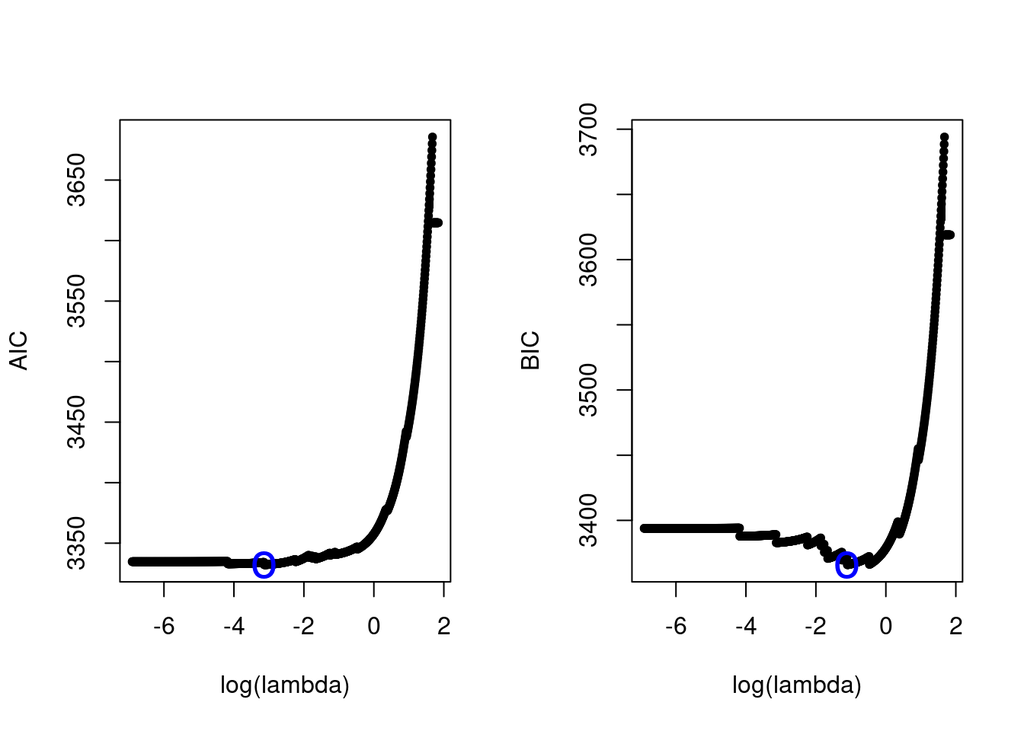

```r
wm.a4 <- which.min(metrics4[, 1])
wm.b4 <- which.min(metrics4[, 2])

# Visualization of metrics plot
par(mfrow=c(1,2))
plot(log(g4$lambda), metrics4[, 1], type="b", pch=20, xlab="log(lambda)", ylab="AIC")
points(log(g4$lambda)[wm.a4], metrics4[wm.a4, 1], pch="o", col="blue", cex=2)
plot(log(g4$lambda), metrics4[, 2], type="b", pch=20, xlab="log(lambda)", ylab="BIC")
points(log(g4$lambda)[wm.b4], metrics4[wm.b4, 2], pch="o", col="blue", cex=2)
```

```r
# Print Results
coef4a <- coef(g4, s=g4$lambda[wm.a4])
cat("The variables included in final model based on AIC : ", coef4a@Dimnames[[1]][which(coef4a != 0)][-1], sep = "\t")
```

```
## The variables included in final model based on AIC :     zn  indus   chas    nox rm  dis rad ptratio black   lstat   medv
```

```r
cat("The number of variables included in final model based on AIC : ", length(coef4a@Dimnames[[1]][which(coef4a != 0)][-1]))
```

```
## The number of variables included in final model based on AIC :  11
```

```r
cat("The value of its AIC : ", metrics4[wm.a4, 1])
```

```
## The value of its AIC :  3332.155
```

```r
coef4b <- coef(g4, s=g4$lambda[wm.b4])
cat("The variables included in final model based on BIC : ", coef4b@Dimnames[[1]][which(coef4b != 0)][-1], sep="\t")
```

```
## The variables included in final model based on BIC :     dis rad black   lstat   medv
```

```r
cat("The number of variables included in final model based on BIC : ", length(coef4b@Dimnames[[1]][which(coef4b != 0)][-1]))
```

```
## The number of variables included in final model based on BIC :  5
```

```r
cat("The value of its BIC : ", metrics4[wm.b4, 2])
```

```
## The value of its BIC :  3365.955
```

# Problem 5

Repeat Q3, replacing $\hat{\sigma_1}$ with $\hat{\sigma_3} = \sqrt{\frac{1}{n-d}\sum_{i=1}^n(y_i - \hat{\beta_0^{lasso}} - x_i^T \hat{\beta^{lasso}}^2)}$

```r
# ---------- Problem5 ----------
# Repate Q3, replacing sigma1 with sigma3 which is calculated from \beta_{lasso}
# Workflows of Problem 5
# 1. Define new sigma function called sigma_formula3
# 2. Define hyperparameter grid lambda.
# 3. Train model in lambda grid(using glmnet function)
# 4. Repeat the steps through lambda grid
#   4.1 Calculate d and prediction from each lambda.
#   4.2 Calculate sigma3 using sigma_formula3 function.
#   4.3 Calculate AIC and BIC from prediction and store results into metrics5.
# 4. Evaluate models.

# \sigma 3
sigma_formula3 <- function(y, pred, n, d) {
  res <- sqrt(sum((y- pred)^2) / (n - d))
  return(res)
}

# Set hyper parameters grid lambda
lambda <- 10^seq(0.8, -3, length=1000)

# Train model
g5 <- glmnet(x, y, alpha=1, lambda=lambda)

# model evaluation
metrics5 <- matrix(0, length(g5$lambda), 2)
for (i in 1:length(g5$lambda)) {
  d <- g5$df[i] + 1
  pred <- predict(g5, s=g5$lambda[i], newx=model.matrix(~., x)[,-1])
  sigma3 <- sigma_formula3(y, pred, n, d)
  ltheta <- likelihood2(y, pred, sigma3)
  metrics5[i, 1] <- aic(ltheta, d)
  metrics5[i, 2] <- bic(ltheta, d, n)
}

# find the smallest number of variables based on AIC and BIC
colnames(metrics5) <- c('AIC', 'BIC')
metrics5[sample(1:800, 10, replace=FALSE),]
```

```
##            AIC      BIC
##  [1,] 3427.052 3439.731
##  [2,] 3334.750 3393.921
##  [3,] 3361.257 3382.390
##  [4,] 3341.456 3366.816
##  [5,] 3340.808 3366.167
##  [6,] 3334.800 3393.972
##  [7,] 3393.292 3405.972
##  [8,] 3349.439 3370.572
##  [9,] 3341.062 3366.421
## [10,] 3382.654 3395.333
```

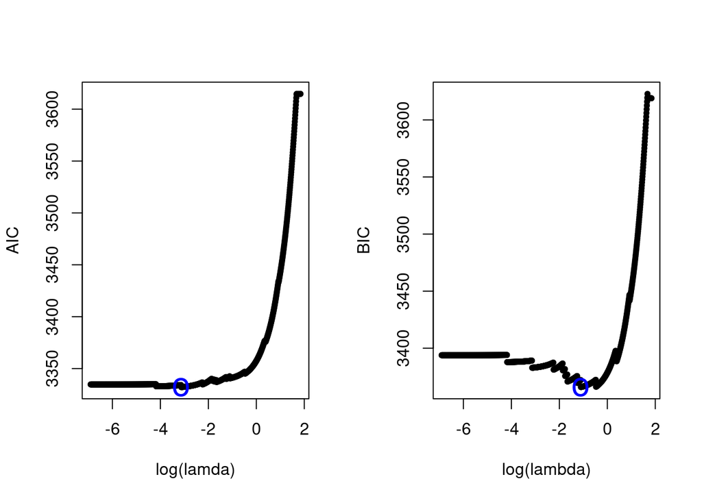

```r
wm.a5 <- which.min(metrics5[, 1])
wm.b5 <- which.min(metrics5[, 2])

# Visualization of metrics plot
par(mfrow=c(1,2))
plot(log(g5$lambda), metrics5[, 1], type="b", pch=20, xlab="log(lamda)", ylab="AIC")
points(log(g5$lambda)[wm.a5], metrics5[wm.a5, 1], pch="o", col="blue", cex=2)
plot(log(g5$lambda), metrics5[, 2], type="b", pch=20, xlab="log(lambda)", ylab="BIC")
points(log(g5$lambda)[wm.b5], metrics5[wm.b5, 2], pch="o", col="blue", cex=2)
```

```r
# Print Results
coef5a <- coef(g5, s=g5$lambda[wm.a5])
cat("The variables included in final model based on AIC : ", coef5a@Dimnames[[1]][which(coef5a != 0)][-1], sep="\t")
```

```
## The variables included in final model based on AIC :     zn  indus   chas    nox rm  dis rad ptratio black   lstat   medv
```

```r
cat("The number of variables included in final model based on AIC : ", length(coef5a@Dimnames[[1]][which(coef5a != 0)][-1]))
```

```
## The number of variables included in final model based on AIC :  11
```

```r
cat("The value of its AIC : ", metrics5[wm.a5, 1])
```

```
## The value of its AIC :  3332.176
```

```r
coef5b <- coef(g5, s=g5$lambda[wm.b5])
cat("The variables included in final model based on BIC : ", coef5b@Dimnames[[1]][which(coef5b != 0)][-1], sep="\t")
```

```
## The variables included in final model based on BIC :     dis rad black   lstat   medv
```

```r
cat("The number of variables included in final model based on BIC : ", length(coef5b@Dimnames[[1]][which(coef5b != 0)][-1]))
```

```
## The number of variables included in final model based on BIC :  5
```

```r
cat("The value of its BIC : ", metrics5[wm.b5, 2])
```

```
## The value of its BIC :  3365.98
```

# Problem 6

Randomly separate a training set (tran) and a test set (test), using the following R code

```
set.seed(4321)
tran <- sample(nrow(x), 400)
test <- setdiff(1:nrow(x), tran)
```

Find the best subset based on the training set, i.e., $n = 400$. In order to find the best subset, you should consider 5 different ways from Q1 to Q5. Since each question requires to find the best subset based on both $AIC$ and $BIC$, you actually have 10 different ways to find the best subset. Let us denote them by $M_1, M_2, ..., M_{10}$. Note that the best subsets from 10 different ways can be overlapped. After you find 10 best subsets from the training set, compute the test errors using $\frac{1}{106}\sum_{i=1}^{106}(y_i - \hat{\beta_0^{ols}} - x_i^T \hat{\beta^{ols}})^2$ for each subset. For computation of the test error, $(\hat{\beta_0^{ols}},\hat{\beta^{ols}})$ should be estimated from the training set while $i = 1, ... , 106$ is an index of the test set. Finally, provide the variable selection result from the training set and the test error (TE) for each subset using the following table,

[output not shown]

In the table, write ‘1’ if the corresponding variable is included in the model, otherwise ‘0’. Who is winner?

```r
# ---------- Problem 6 ---------- #
# Workflows of problem 6
# 1. Randomly separate a training set and test set.
# 2. Declare result matrix called res and initialize with 0.
# 3. For each training set, repeat all steps what we have done in problem 1 ~ 5.
# 4. Update the value of selected variables(columns) for each model(rows) to 1.
# 5. Calculate training error TE using MAE.
# 6. Check the result and find the winner.


# Randomly separate a training set and test set
set.seed(4321)
tran <- sample(n, 400)
test <- setdiff(1:nrow(x), tran)

# Define function for finding 10 best subsets from the training set.
# This will return \beta_{ols} and selected_variables
find_best_model <- function(x, y, model_numbers) {
  # if : regsubsets function for M_1 ~ M_4
  # else : glmnet function for M_5 ~ M10
  if (model_numbers <= 4) {
    # train model
    g <- regsubsets(x, y, nvmax=13, nbest=1)

    # model evaluation
    metrics <- matrix(0, 13, 1)
    for (i in 1:13) {
      coefi <- coef(g, id=i)
      d <- length(coefi)
      # if : evaluation based on sigma1
      # else : evaluation based on sigma2
      if (model_numbers <= 2) {
        sigma1 <- sigma_formula1(y, ybar, n)
        ltheta <- likelihood(x, y, coefi, sigma1)
      } else {
        sigma2 <- sigma_formula2(x, y, coefi, n, d)
        ltheta <- likelihood(x, y, coefi, sigma2)
      }
      # if : evaluation based on AIC
      # else : evaluation based on BIC
      if (model_numbers %% 2 != 0) {
        metrics[i, 1] <- aic(ltheta, d)
      } else {
        metrics[i, 1] <- bic(ltheta, d, n)
      }
    }
    # Find the smallest number of variables and return results
    wm <- which.min(metrics)
    min_vars <- names(coef(g, id=wm)[-1])
    min_coef <- coef(g, id=wm)
    return(list(min_vars, min_coef))
  } else {
    lambda <- 10^seq(0.8, -3, length=1000)
    g <- glmnet(x, y, alpha=1, lambda=lambda)

    # model evaluation
    metrics <- matrix(0, length(g$lambda), 1)
    for (i in 1:length(g$lambda)) {
      d <- g$df[i] + 1
      pred <- predict(g, s=g$lambda[i], newx=model.matrix(~., x)[,-1])
      # if : evaluation based on sigma1
      # elif : evaluation based on sigma2
      # else : evaluation based on sigma3
      if (model_numbers <= 6) {
        sigma1 <- sigma_formula1(y, ybar, n)
        ltheta <- likelihood2(y, pred, sigma1)
      } else if (model_numbers <= 8) {
        xvars <- rownames(coef(g, s=g$lambda[i]))[-1]
        sigma2 <- sigma2_lasso(d, xvars)
        ltheta <- likelihood2(y, pred, sigma2)
      } else {
        sigma3 <- sigma_formula3(y, pred, n, d)
        ltheta <- likelihood2(y, pred, sigma3)
      }
      # if : evaluation based on AIC
      # else : evaluation based on BIC
      if (model_numbers %% 2 != 0) {
        metrics[i, 1] <- aic(ltheta, d)
      } else {
        metrics[i, 1] <- bic(ltheta, d, n)
      }
    }
    # Find the smallest number of variables and return results
    wm <- which.min(metrics)
    coefm <- coef(g, s=g$lambda[wm])
    min_vars <- coefm@Dimnames[[1]][which(coefm != 0)][-1]
    min_coef <- coefm
    return(list(min_vars, min_coef))
  }
}

# Define function for calculuting test error based on MSE
calculate_test_error <- function(x, y, xvars, coef_, model_number) {
  # if : Calculate test error based on regsubsets
  # else : Calculate test error based on glmnet
  if (model_number <= 4) {
    pred <- model.matrix(~., test_X[, xvars]) %*% coef_
  } else {
    pred <- model.matrix(~., test_X) %*% coef_
  }
  test_error <- mean((test_y - pred)^2)
  return(test_error)
}

# Declare result matrix (10 X 14)
res <- matrix(0, 10, ncol(x) + 1)
colnames(res) <- c(colnames(x), 'TE')
rownames(res) <- c('Q1-AIC', 'Q1-BIC', 'Q2-AIC', 'Q2-BIC', 'Q3-AIC', 'Q3-BIC', 'Q4-AIC', 'Q4-BIC', 'Q5-AIC', 'Q5-BIC')

for (i in 1:10) {
  train_X <- x[tran, ]
  train_y <- y[tran]
  test_X <- x[test,]
  test_y <- y[test]

  # Find the best model from each problems
  train_result <- find_best_model(train_X, train_y, i)
  xvars <- as.vector(train_result[[1]])
  # Calculate Test Error based on MSE and selected variables
  res[i, 'TE'] <- calculate_test_error(test_X, test_y, xvars, train_result[[2]], i)
  res[i , xvars] <- 1
}

# Check the table
res
```

```
##        zn indus chas nox rm age dis rad tax ptratio black lstat medv       TE
## Q1-AIC  1     0    0   1  0   0   1   1   0       0     1     0    1 14.58761
## Q1-BIC  0     0    0   0  0   0   0   1   0       0     0     1    0 13.68795
## Q2-AIC  1     0    0   1  0   0   1   1   0       1     1     0    1 14.55877
## Q2-BIC  0     0    0   0  0   0   0   1   0       0     1     1    0 14.50585
## Q3-AIC  1     0    1   0  0   0   1   1   0       0     1     1    1 13.56147
## Q3-BIC  0     0    0   0  0   0   0   1   0       0     1     1    1 13.21359
## Q4-AIC  1     1    1   1  1   0   1   1   0       1     1     1    1 13.56020
## Q4-BIC  0     0    0   0  0   0   1   1   0       0     1     1    1 13.61914
## Q5-AIC  1     1    1   1  1   0   1   1   0       1     1     1    1 13.56020
## Q5-BIC  0     0    0   0  0   0   0   1   0       0     1     1    1 13.21359
```

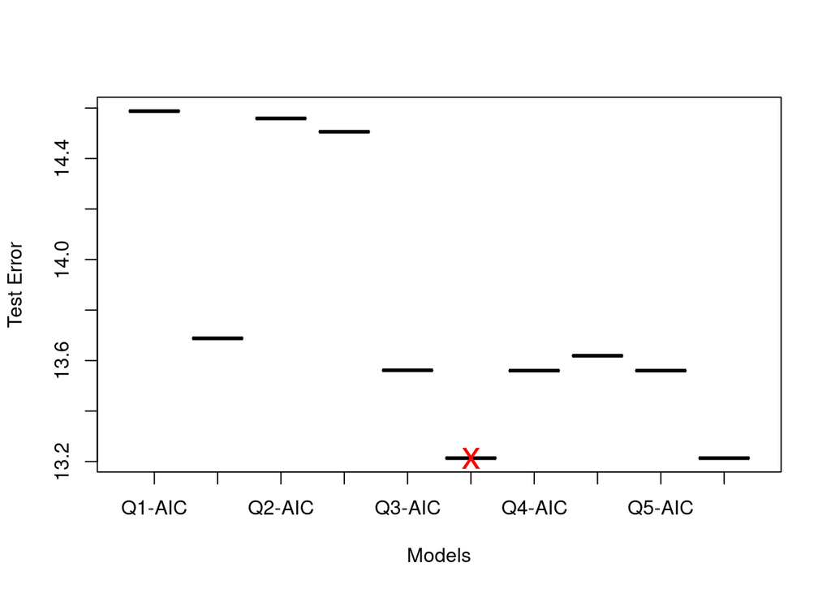

```r
# Visualization result
wm.t <- which.min(res[ , 'TE'])
plot(factor(rownames(res)), res[ , 'TE'], type="b", pch=20, cex=0.2, xlab="Models", ylab="Test Error")
points(factor(rownames(res))[wm.t], res[wm.t, 'TE'], pch="x", col="red", cex=2)
```